# MRI separate dense validation - model6 RF vs model8 process

This report keeps the Mulloon Rehydration Initiative soil-moisture probes separate from `reports/analyses/unified_dense_validation` while using the same model-agnostic validation and local-spiking figure pipeline.

## Data preparation

| site | source_table | rows | models | points_unique | dates | date_min | date_max | seasons | eligible_points_stage2 | smips_columns_present | note |
| --- | --- | --- | --- | --- | --- | --- | --- | --- | --- | --- | --- |
| MRI | /Volumes/Dmitry_work/borevitz_projects/DMM_validation/outputs/mri_dense_validation/mri_model6_model8_predictions.csv | 60518.000 | model6_rf,model8_process | 18.000 | 1931.000 | 2020-09-25 | 2026-06-03 | autumn,spring,summer,winter | 18.000 | yes |  |

Preparation details:

- Source percent CSV: `/Volumes/Dmitry_work/borevitz_projects/Data/MRI_data/SM_combined_cleaned/SM(%)_combined_cleaned.csv`
- Source GPKG: `/Volumes/Dmitry_work/borevitz_projects/Data/MRI_data/MulloonRehydrationInitiative.gpkg`
- Coordinate and label layer: `Soil_Moisture_Probes`
- Logger serial crosswalk layer: `HT_Measurement_Point_Matrix`
- Metadata PDF reference: `/Volumes/Dmitry_work/borevitz_projects/Data/MRI_data/SM_metadata.pdf`
- Daily profile observations: 30259 rows from 18 probes
- Dates used: 2020-09-25 to 2026-06-03 (1931 dates)
- Feature/prediction bbox W/S/E/N: `(149.5768581609843, -35.293447188943425, 149.6383966184215, -35.192121174251156)`
- Daily date policy: UTC timestamps converted to `Australia/Sydney` before daily aggregation
- Observation filter: `1e-06 < soil_moisture_percent <= 100.0`
- Profile mean policy: daily mean per depth channel, then unweighted profile mean across valid depth channels
- Coordinate policy: lon/lat from Soil_Moisture_Probes GPKG layer; HT_Measurement_Point_Matrix used only for logger serial to Irrimax_ID crosswalk

Filtered cells: 303 low/zero and 10305 above 100.0% VWC.

## Stage 1 - independent validation

### Overall skill

| site | base_model | n | nse | pearson_r | rmse | ubrmse | bias | mae |
| --- | --- | --- | --- | --- | --- | --- | --- | --- |
| MRI | model6_rf | 30259.000 | -0.016 | 0.527 | 10.067 | 8.502 | -5.390 | 7.980 |
| MRI | model8_process | 30259.000 | 0.011 | 0.590 | 9.933 | 8.205 | -5.599 | 8.051 |

### Seasonal skill

| site | base_model | season | n | nse | pearson_r | rmse | ubrmse | bias | mae |
| --- | --- | --- | --- | --- | --- | --- | --- | --- | --- |
| MRI | model6_rf | spring | 7505.000 | -0.024 | 0.519 | 10.138 | 8.568 | -5.419 | 8.099 |
| MRI | model6_rf | summer | 7129.000 | 0.084 | 0.592 | 9.930 | 8.530 | -5.083 | 7.780 |
| MRI | model6_rf | autumn | 7887.000 | 0.011 | 0.524 | 10.003 | 8.604 | -5.103 | 7.869 |
| MRI | model6_rf | winter | 7738.000 | -0.441 | 0.275 | 10.187 | 8.277 | -5.938 | 8.161 |
| MRI | model8_process | spring | 7505.000 | -0.095 | 0.613 | 10.484 | 8.009 | -6.765 | 8.633 |
| MRI | model8_process | summer | 7129.000 | 0.217 | 0.664 | 9.181 | 8.141 | -4.245 | 7.331 |
| MRI | model8_process | autumn | 7887.000 | 0.080 | 0.565 | 9.650 | 8.464 | -4.636 | 7.726 |
| MRI | model8_process | winter | 7738.000 | -0.481 | 0.377 | 10.326 | 7.861 | -6.696 | 8.482 |

### Dry/wet observed-state bias

| site | base_model | obs_moisture_quantile | n | obs_mean | pred_mean | rmse | ubrmse | bias | mae |
| --- | --- | --- | --- | --- | --- | --- | --- | --- | --- |
| MRI | model6_rf | dry_q1 | 7565.000 | 16.935 | 21.259 | 7.282 | 5.858 | 4.324 | 5.407 |
| MRI | model6_rf | q2 | 7565.000 | 27.692 | 24.522 | 4.979 | 3.839 | -3.169 | 3.763 |
| MRI | model6_rf | q3 | 7564.000 | 34.706 | 27.071 | 8.971 | 4.710 | -7.635 | 7.667 |
| MRI | model6_rf | wet_q4 | 7565.000 | 42.745 | 27.662 | 15.719 | 4.428 | -15.083 | 15.083 |
| MRI | model8_process | dry_q1 | 7565.000 | 16.935 | 21.227 | 6.837 | 5.323 | 4.292 | 5.293 |
| MRI | model8_process | q2 | 7565.000 | 27.692 | 23.941 | 5.057 | 3.391 | -3.751 | 3.974 |
| MRI | model8_process | q3 | 7564.000 | 34.706 | 26.662 | 9.045 | 4.135 | -8.044 | 8.047 |
| MRI | model8_process | wet_q4 | 7565.000 | 42.745 | 27.853 | 15.509 | 4.331 | -14.892 | 14.892 |

### Paired model comparison

Positive `mean_delta_abs_error` means model8 has lower absolute error than model6 on matched probe-date observations.

| site | model_a | model_b | n_matched | mean_delta_abs_error | rmse_a | rmse_b | bias_a | bias_b |
| --- | --- | --- | --- | --- | --- | --- | --- | --- |
| MRI | model6_rf | model8_process | 30259.000 | -0.072 | 10.067 | 9.933 | -5.390 | -5.599 |

### Most notable terrain/model-input strata

| site | base_model | terrain_var | n_strata | nse_min | nse_max | rmse_min | rmse_max | bias_min | bias_max |
| --- | --- | --- | --- | --- | --- | --- | --- | --- | --- |
| MRI | model6_rf | northness | 3.000 | -1.321 | 0.412 | 7.101 | 13.330 | -11.292 | 0.817 |
| MRI | model6_rf | twi | 3.000 | -1.606 | 0.296 | 8.255 | 12.708 | -10.517 | -0.207 |
| MRI | model6_rf | elevation | 3.000 | -0.719 | 0.355 | 8.086 | 12.743 | -10.145 | -0.688 |
| MRI | model6_rf | soil_bdw | 3.000 | -0.262 | 0.303 | 8.850 | 11.969 | -8.773 | -1.355 |
| MRI | model6_rf | slope | 3.000 | -0.805 | 0.260 | 8.851 | 10.763 | -7.708 | -0.130 |
| MRI | model6_rf | hli | 3.000 | -0.346 | 0.191 | 9.092 | 11.394 | -8.024 | -1.182 |
| MRI | model6_rf | soil_awc | 3.000 | -1.160 | 0.286 | 8.954 | 11.114 | -8.546 | -2.351 |
| MRI | model6_rf | soil_clay | 3.000 | -0.223 | 0.147 | 8.832 | 11.201 | -7.357 | -3.116 |
| MRI | model8_process | northness | 3.000 | -1.280 | 0.458 | 6.820 | 13.212 | -11.332 | 0.203 |
| MRI | model8_process | twi | 3.000 | -1.521 | 0.372 | 7.794 | 12.497 | -10.768 | -0.219 |
| MRI | model8_process | elevation | 3.000 | -0.546 | 0.353 | 8.093 | 12.084 | -9.305 | -1.328 |
| MRI | model8_process | slope | 3.000 | -0.702 | 0.339 | 8.363 | 10.599 | -8.021 | -0.127 |
| MRI | model8_process | soil_bdw | 3.000 | -0.235 | 0.266 | 8.566 | 11.839 | -8.506 | -2.368 |
| MRI | model8_process | hli | 3.000 | -0.464 | 0.275 | 8.605 | 10.849 | -7.402 | -1.621 |
| MRI | model8_process | soil_awc | 3.000 | -0.995 | 0.240 | 8.616 | 10.683 | -8.443 | -3.374 |
| MRI | model8_process | ppet_365 | 3.000 | -0.457 | 0.251 | 8.445 | 11.064 | -7.345 | -3.019 |

## Stage 2 - local-spiking sensitivity

Stage 2 uses the same sparse local-calibration design as the unified dense validation, but only on MRI probes. The strict `spatiotemporal_block` remains the main transfer test.

### Uncalibrated baseline

| site | base_model | model_track | n | nse | pearson_r | rmse | ubrmse | bias |
| --- | --- | --- | --- | --- | --- | --- | --- | --- |
| MRI | model6_rf | statistical_rf | 30259.000 | -0.016 | 0.527 | 10.067 | 8.502 | -5.390 |
| MRI | model8_process | process_bucket | 30259.000 | 0.011 | 0.590 | 9.933 | 8.205 | -5.599 |

### NSE target summary

| site | base_model | target_status | selection_strategy | budget_label | calibration_points | method | nse_median | pearson_r_median | rmse_median | ubrmse_median | bias_median | n_replicates |
| --- | --- | --- | --- | --- | --- | --- | --- | --- | --- | --- | --- | --- |
| MRI | model6_rf | reached NSE ≥ 0.4 | global_prediction_extremes | 50% | 9.000 | residual_ridge | 0.404 | 0.664 | 8.127 | 8.010 | -1.376 | 1.000 |
| MRI | model8_process | reached NSE ≥ 0.4 | global_prediction_extremes | 3 | 3.000 | residual_ridge | 0.487 | 0.747 | 7.237 | 7.232 | -0.272 | 1.000 |

### Best strict-block local calibration design

| site | base_model | selection_strategy | budget_label | calibration_points | method | nse_median | pearson_r_median | rmse_median | ubrmse_median | bias_median | n_replicates |
| --- | --- | --- | --- | --- | --- | --- | --- | --- | --- | --- | --- |
| MRI | model6_rf | field_knowledge_wetdry_proxy | 50% | 9.000 | bias_offset | 0.148 | 0.428 | 6.410 | 6.389 | 0.521 | 1.000 |
| MRI | model8_process | field_knowledge_wetdry_proxy | 50% | 9.000 | bias_offset | 0.257 | 0.517 | 5.988 | 5.966 | 0.506 | 1.000 |

### Process-vs-statistical response under random placement

| site | budget_label | calibration_points | method | statistical_rmse_gain_median | process_rmse_gain_median | process_minus_statistical_rmse_gain_median | fraction_process_wins | n_replicates |
| --- | --- | --- | --- | --- | --- | --- | --- | --- |
| MRI | 1 | 1.000 | affine | 0.319 | 0.302 | 0.310 | 0.750 | 20.000 |
| MRI | 1 | 1.000 | bias_offset | 0.685 | 1.086 | 0.124 | 0.800 | 20.000 |
| MRI | 1 | 1.000 | residual_ridge | -2.194 | -0.917 | 0.715 | 0.900 | 20.000 |
| MRI | 1 | 1.000 | seasonal_offset | 0.655 | 1.009 | 0.225 | 0.850 | 20.000 |
| MRI | 10 | 10.000 | affine | -2.135 | -1.052 | 1.127 | 0.900 | 20.000 |
| MRI | 10 | 10.000 | bias_offset | -0.056 | -0.103 | 0.064 | 0.600 | 20.000 |
| MRI | 10 | 10.000 | residual_ridge | -3.112 | -3.831 | 0.000 | 0.550 | 20.000 |
| MRI | 10 | 10.000 | seasonal_offset | -0.308 | -0.205 | 0.265 | 0.800 | 20.000 |
| MRI | 25% | 5.000 | affine | -1.073 | -0.174 | 0.755 | 0.700 | 20.000 |
| MRI | 25% | 5.000 | bias_offset | 0.688 | 0.712 | -0.014 | 0.550 | 20.000 |
| MRI | 25% | 5.000 | residual_ridge | -0.079 | -0.091 | 0.014 | 0.450 | 20.000 |
| MRI | 25% | 5.000 | seasonal_offset | 0.550 | 0.595 | 0.123 | 0.700 | 20.000 |
| MRI | 3 | 3.000 | affine | -1.695 | -1.588 | 0.367 | 0.700 | 20.000 |
| MRI | 3 | 3.000 | bias_offset | 0.177 | 0.227 | 0.176 | 0.900 | 20.000 |
| MRI | 3 | 3.000 | residual_ridge | -0.956 | -1.180 | 0.236 | 0.600 | 20.000 |
| MRI | 3 | 3.000 | seasonal_offset | 0.021 | 0.091 | 0.382 | 0.900 | 20.000 |
| MRI | 5 | 5.000 | affine | -0.313 | 0.047 | 0.403 | 0.850 | 20.000 |
| MRI | 5 | 5.000 | bias_offset | 0.381 | 0.659 | 0.113 | 0.600 | 20.000 |
| MRI | 5 | 5.000 | residual_ridge | 0.161 | -0.257 | -0.180 | 0.300 | 20.000 |
| MRI | 5 | 5.000 | seasonal_offset | -0.035 | 0.431 | 0.207 | 0.950 | 20.000 |
| MRI | 50% | 9.000 | affine | -1.112 | -0.136 | 1.409 | 0.800 | 20.000 |
| MRI | 50% | 9.000 | bias_offset | 0.831 | 0.924 | 0.109 | 0.550 | 20.000 |
| MRI | 50% | 9.000 | residual_ridge | -3.734 | -3.519 | 0.049 | 0.600 | 20.000 |
| MRI | 50% | 9.000 | seasonal_offset | 0.600 | 0.781 | 0.232 | 0.750 | 20.000 |

## Stage 1 Figures

### Stage 1 overall model skill

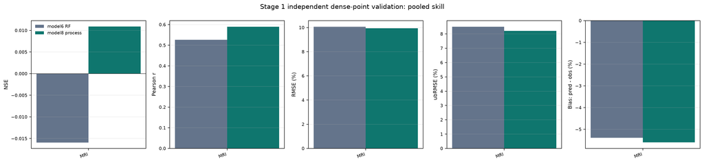

Stage 1 overall model skill

Independent MRI probe-date validation before local calibration.

### Seasonal bias

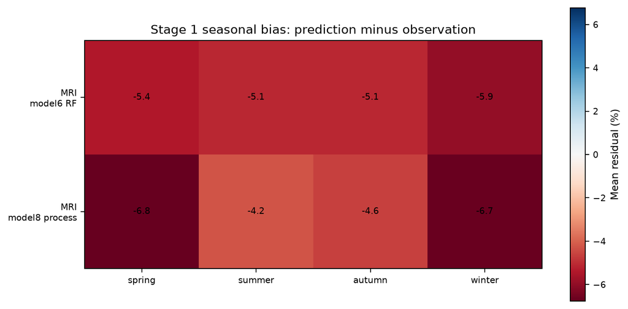

Seasonal bias

Mean residual by southern-hemisphere season; positive values mean overprediction.

### Dry/wet observed-state bias

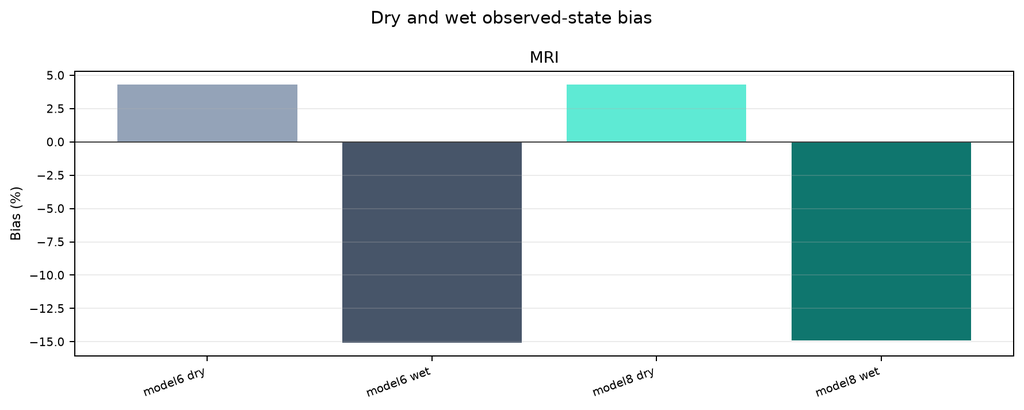

Dry/wet observed-state bias

Bias in observed soil-moisture quartiles.

### Observed vs predicted by season

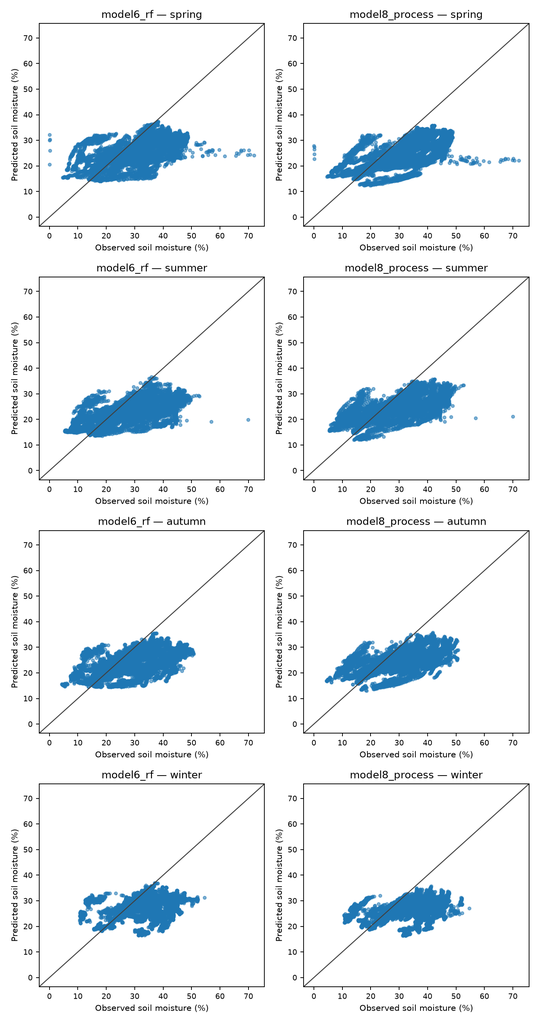

Observed vs predicted by season

Point-date observations compared with model predictions by season.

### Spatial-mean time series

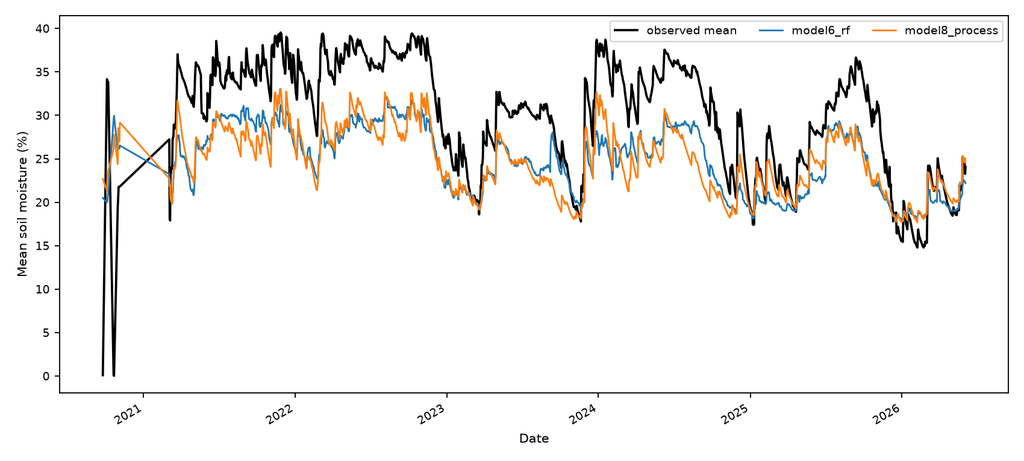

Spatial-mean time series

Date-wise MRI observed soil moisture compared with model6 and model8 spatial means.

### Mean residual time series

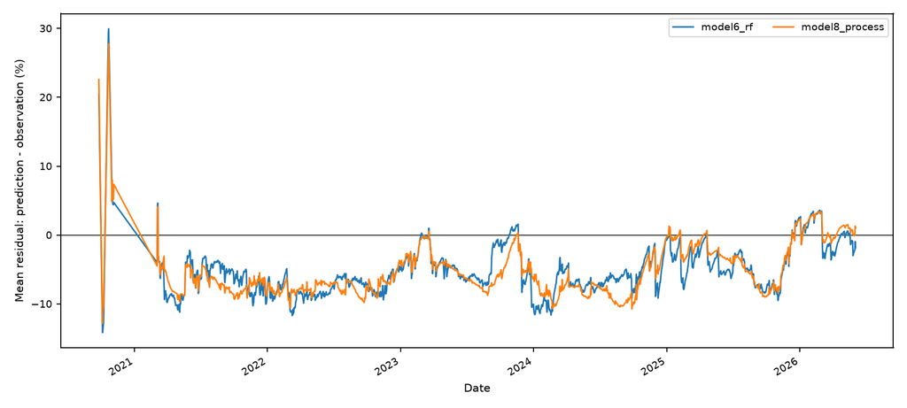

Mean residual time series

Date-wise mean prediction residuals.

### Seasonal residual distributions

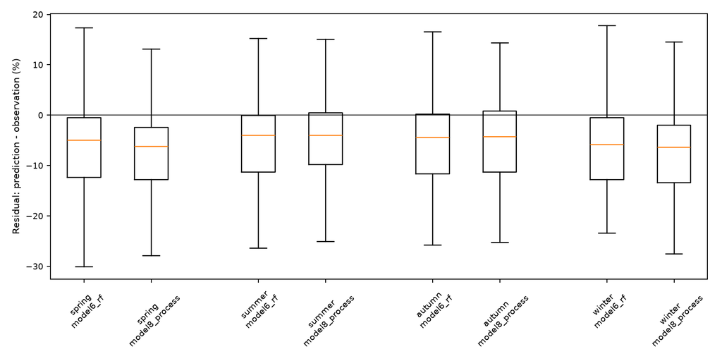

Seasonal residual distributions

Residual spread by season and model.

### Model6 point RMSE

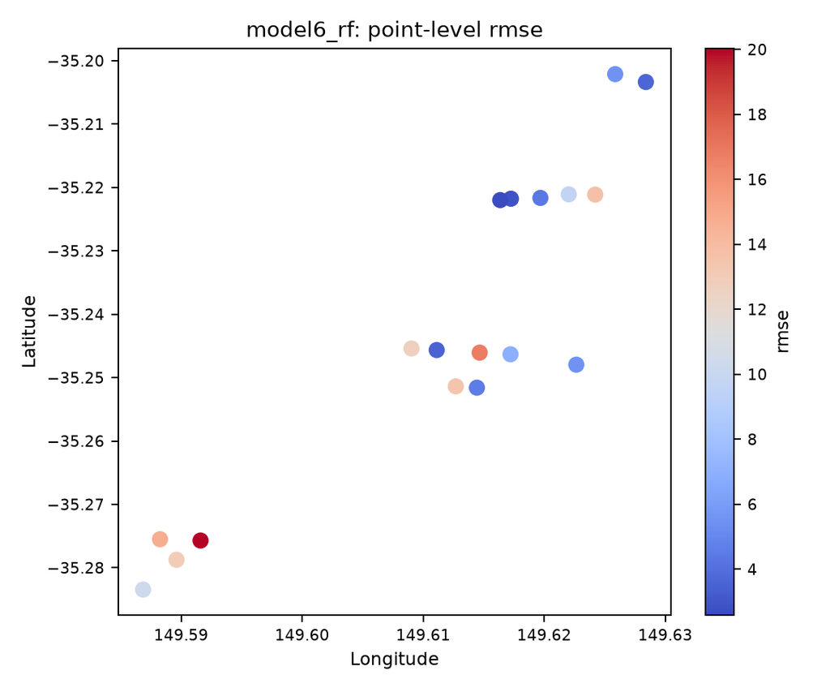

Model6 point RMSE

Point-level model6 RMSE at MRI probe coordinates.

### Model8 point RMSE

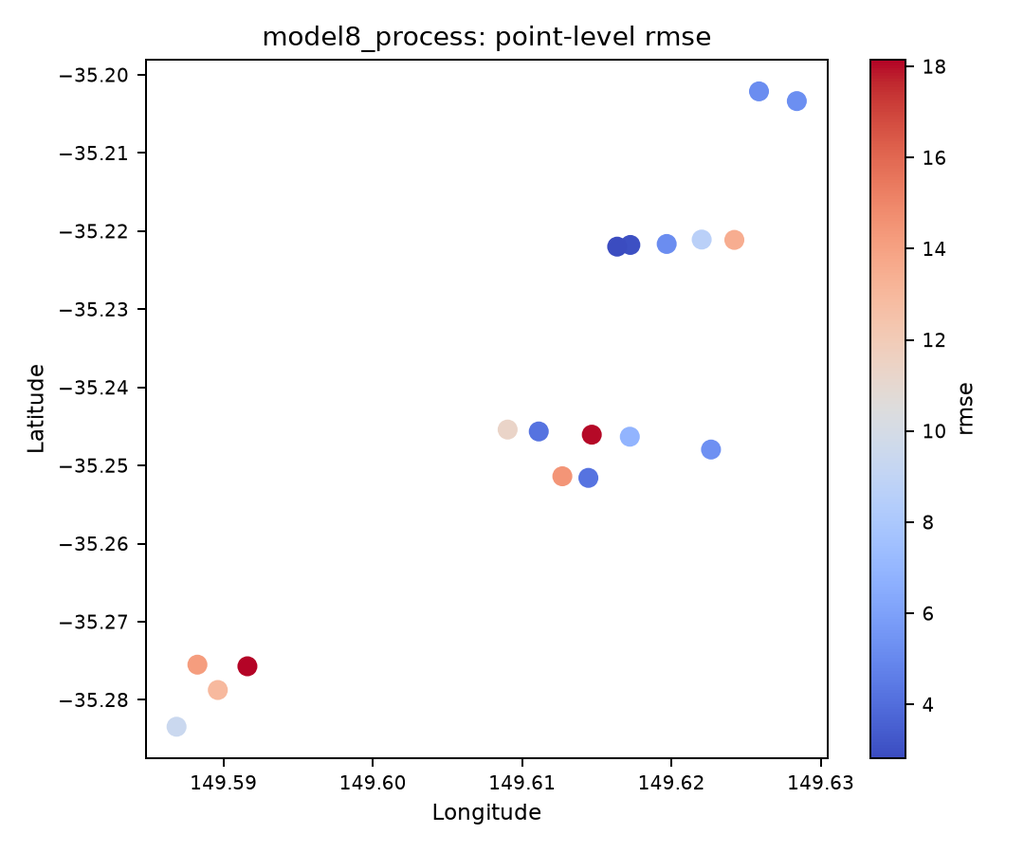

Model8 point RMSE

Point-level model8 RMSE at MRI probe coordinates.

### Paired model error difference

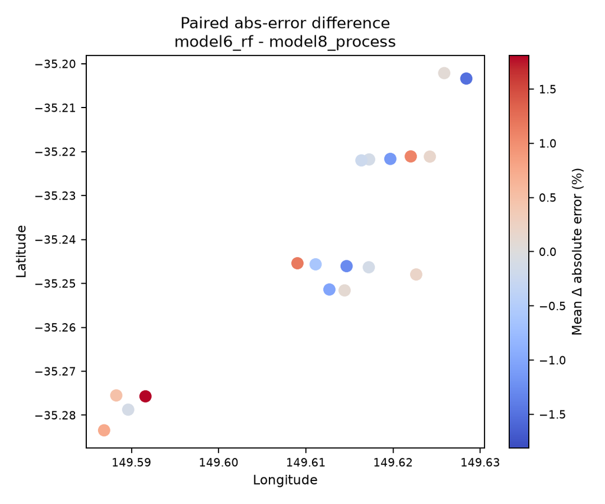

Paired model error difference

Mean paired absolute-error difference at MRI probe coordinates.

### Model6 interpolated RMSE surface

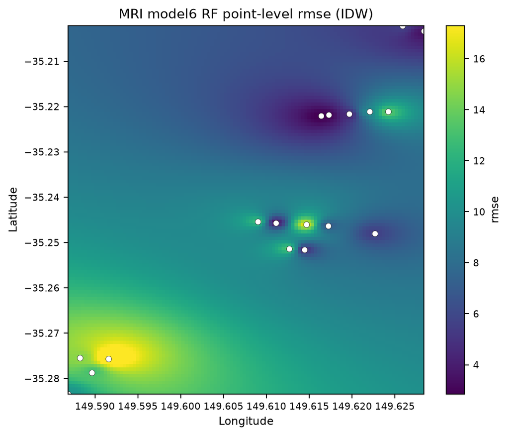

Model6 interpolated RMSE surface

IDW interpolation of point-level RMSE for visual diagnosis only.

### Model8 interpolated RMSE surface

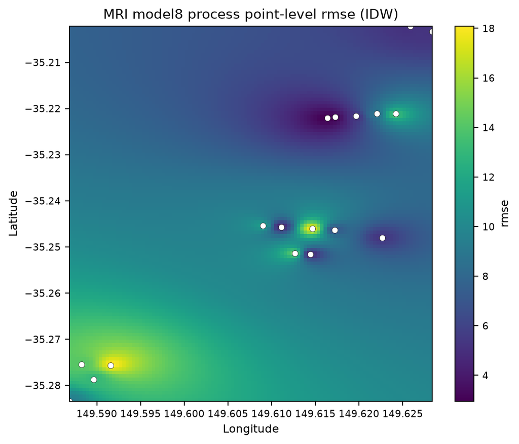

Model8 interpolated RMSE surface

IDW interpolation of point-level RMSE for visual diagnosis only.

## Stage 2 Figures

### Uncalibrated global model skill by dense site

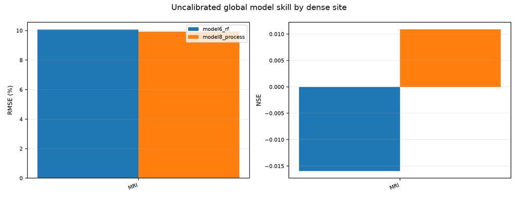

Uncalibrated global model skill by dense site

Baseline RMSE and NSE for model6 RF and model8 process before any local calibration.

### Strict spatio-temporal prior-guided learning curves: RMSE gain

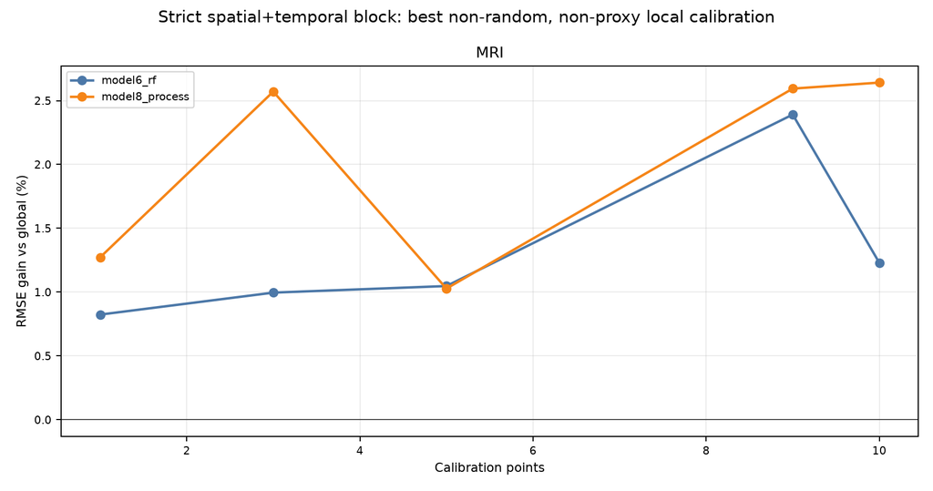

Strict spatio-temporal prior-guided learning curves: RMSE gain

Best RMSE gain from deployable non-random placement priors under the strict spatial+temporal block.

### Strict spatio-temporal prior-guided learning curves: NSE

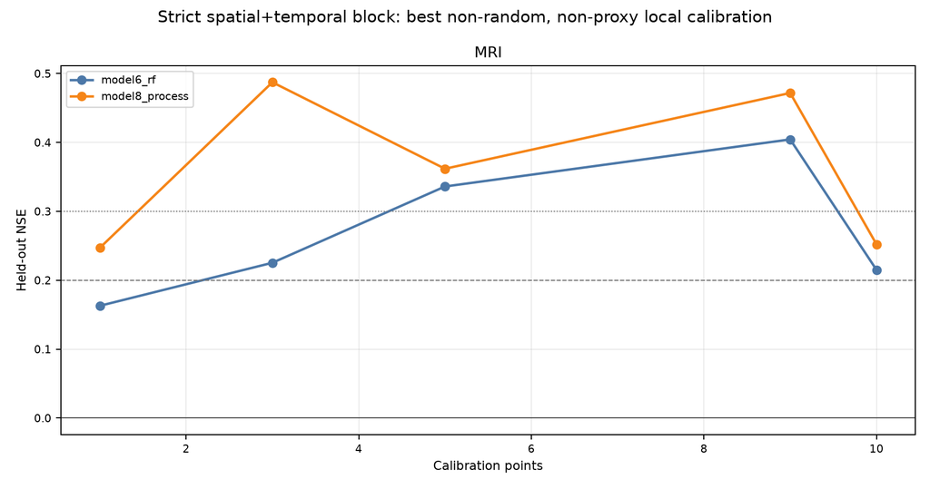

Strict spatio-temporal prior-guided learning curves: NSE

Best held-out NSE from deployable non-random placement priors under the strict spatial+temporal block.

### Process-vs-statistical responsiveness under prior-guided placement

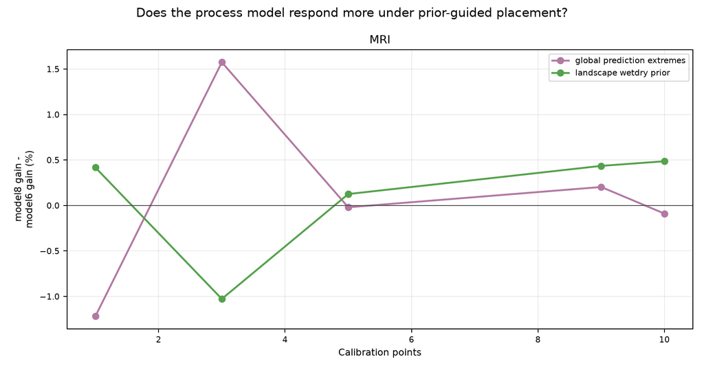

Process-vs-statistical responsiveness under prior-guided placement

Positive values indicate model8 process gains more from the same deployable non-random placement strategy than model6 RF.

### Appendix: random strict spatio-temporal learning curves, RMSE gain

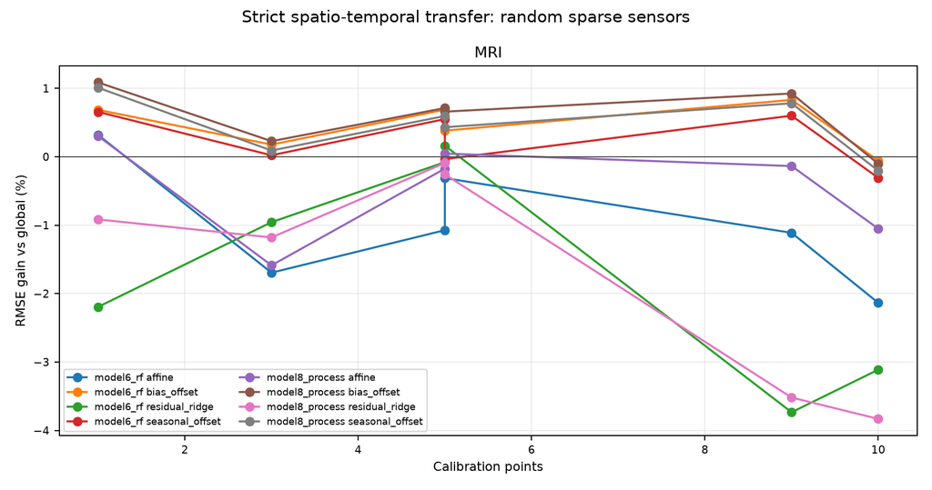

Appendix: random strict spatio-temporal learning curves, RMSE gain

Median RMSE gain from random sparse local sensors when calibration and validation are separated in space and time.

### Appendix: random strict spatio-temporal learning curves, NSE

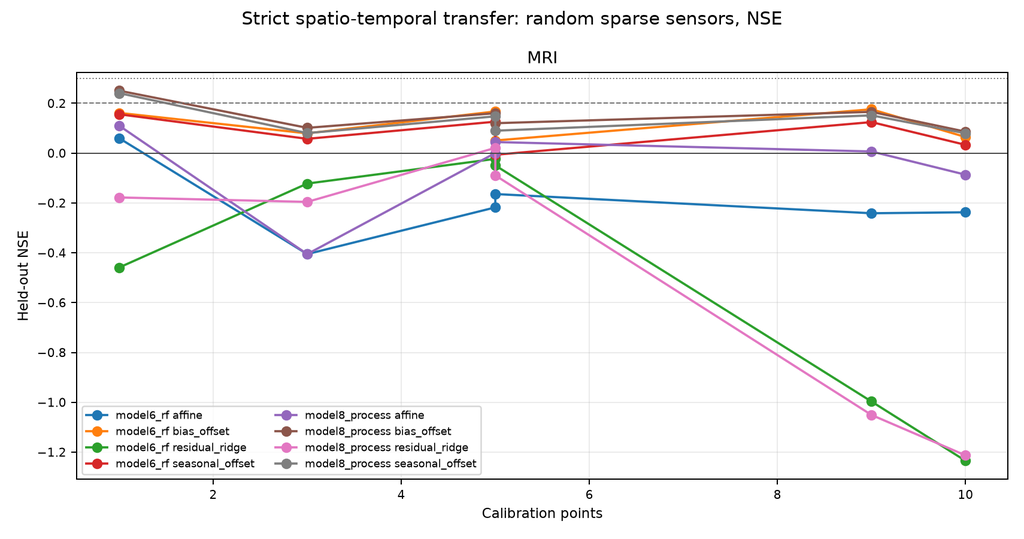

Appendix: random strict spatio-temporal learning curves, NSE

Median held-out NSE from random sparse local sensors when calibration and validation are separated in space and time.

### Appendix: process-vs-statistical responsiveness under random placement

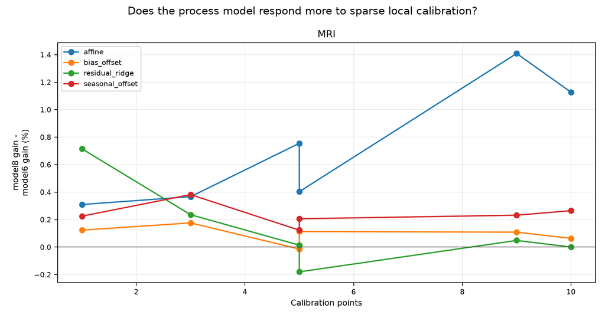

Appendix: process-vs-statistical responsiveness under random placement

Positive values indicate model8 process gains more from the same random sparse calibration budget than model6 RF.

## Output index

- Prepared observations: `/Volumes/Dmitry_work/borevitz_projects/DMM_validation/outputs/mri_dense_validation/mri_profile_mean_observations.csv`
- Probe coordinate crosswalk: `/Volumes/Dmitry_work/borevitz_projects/DMM_validation/outputs/mri_dense_validation/mri_probe_coordinate_crosswalk.csv`
- Model input features: `/Volumes/Dmitry_work/borevitz_projects/DMM_validation/outputs/mri_dense_validation/mri_model_input_features.csv`
- Model-agnostic predictions: `/Volumes/Dmitry_work/borevitz_projects/DMM_validation/outputs/mri_dense_validation/mri_model6_model8_predictions.csv`
- Stage 1 outputs: `/Volumes/Dmitry_work/borevitz_projects/DMM_validation/outputs/mri_dense_validation/stage1_independent_validation`
- Stage 2 outputs: `/Volumes/Dmitry_work/borevitz_projects/DMM_validation/outputs/mri_dense_validation/stage2_local_spiking`
- Report figures: `/Volumes/Dmitry_work/borevitz_projects/DMM_validation/reports/sites/mri_dense_validation/figures`

## Interpretation guardrails

- These MRI outputs are intentionally not merged into the unified dense report yet.
- Interpolated quality surfaces are diagnostic visualizations of point metrics, not gridded model products.
- The MRI source values are treated as volumetric soil water content percent. Values above 100% and zero/negative placeholders are filtered before daily profile means are computed.